# Final Project: Analysis of Earthquake Data

### Introduction

Welcome to my final project! This dataset is called “Significant Earthquakes, 1965-2016, and provides data for global earthquakes above 5.5 from 1965 to 2016. We’re going to be exploring the frequency of earthquakes and magnitude change over ~40 years in the US, and estimating earthquake damage using regression and linear models.

Do you live on the West Coast of the US? Or know people who live in California? My friends are often nervous about the growing number of earthquakes in the Los Angeles and San Jose area. Analysis of earthquake data is important not only to determine safe living areas, but also for disaster reports and predicting future damage to vulnerable countries.

URL: https://www.kaggle.com/usgs/earthquake-database/data

### 1. Load & Tidy the Data

Let’s load the earthquake data!

```r
# load data for the final project
raw_data <- read.csv(file="database.csv", header=TRUE, sep=",")

raw_data %>% head()
```

|  | Date | Time | Latitude | Longitude | Type | Depth | Depth.Error | Depth.Seismic.Stations | Magnitude | Magnitude.Type | Magnitude.Error | Magnitude.Seismic.Stations | Azimuthal.Gap | Horizontal.Distance | Horizontal.Error | Root.Mean.Square | ID | Source | Location.Source | Magnitude.Source | Status |
| --- | --- | --- | --- | --- | --- | --- | --- | --- | --- | --- | --- | --- | --- | --- | --- | --- | --- | --- | --- | --- | --- |
| 1 | 01/02/1965 | 13:44:18 | 19.246 | 145.616 | Earthquake | 131.6 | NA | NA | 6.0 | MW | NA | NA | NA | NA | NA | NA | ISCGEM860706 | ISCGEM | ISCGEM | ISCGEM | Automatic |
| 2 | 01/04/1965 | 11:29:49 | 1.863 | 127.352 | Earthquake | 80.0 | NA | NA | 5.8 | MW | NA | NA | NA | NA | NA | NA | ISCGEM860737 | ISCGEM | ISCGEM | ISCGEM | Automatic |
| 3 | 01/05/1965 | 18:05:58 | -20.579 | -173.972 | Earthquake | 20.0 | NA | NA | 6.2 | MW | NA | NA | NA | NA | NA | NA | ISCGEM860762 | ISCGEM | ISCGEM | ISCGEM | Automatic |
| 4 | 01/08/1965 | 18:49:43 | -59.076 | -23.557 | Earthquake | 15.0 | NA | NA | 5.8 | MW | NA | NA | NA | NA | NA | NA | ISCGEM860856 | ISCGEM | ISCGEM | ISCGEM | Automatic |
| 5 | 01/09/1965 | 13:32:50 | 11.938 | 126.427 | Earthquake | 15.0 | NA | NA | 5.8 | MW | NA | NA | NA | NA | NA | NA | ISCGEM860890 | ISCGEM | ISCGEM | ISCGEM | Automatic |
| 6 | 01/10/1965 | 13:36:32 | -13.405 | 166.629 | Earthquake | 35.0 | NA | NA | 6.7 | MW | NA | NA | NA | NA | NA | NA | ISCGEM860922 | ISCGEM | ISCGEM | ISCGEM | Automatic |

Let’s look at this data. The Date attribute looks hard to work with, and scrolling over to the right -> we see lots of NA rows and some irrelevant attributes. Let’s tidy the data by separating Date into Month, Day, and Year columns, and selecting only the attributes that we want.

In this case, we’re going to use attributes: Year, Time, Latitude, Longitude, Type, Depth, Magnitude, Magnitude.Type, and Source (Location). We’re especially interested in looking at the magnitude of earthquakes per year.

```r
# tidy the data
eq_data <- raw_data %>%
  separate("Date", c("Month", "Day", "Year"), sep = "/") %>%
  type_convert(cols(Year=col_integer())) %>%
  type_convert(cols(Depth=col_integer())) %>%
  type_convert(cols(Magnitude=col_integer())) %>%
  select(3:8, 11:12, 20)  %>%
  drop_na()
eq_data %>% head()
```

|  | Year | Time | Latitude | Longitude | Type | Depth | Magnitude | Magnitude.Type | Source |
| --- | --- | --- | --- | --- | --- | --- | --- | --- | --- |
| 1 | 1965 | 13:44:18 | 19.246 | 145.616 | Earthquake | 131.6 | 6.0 | MW | ISCGEM |
| 2 | 1965 | 11:29:49 | 1.863 | 127.352 | Earthquake | 80.0 | 5.8 | MW | ISCGEM |
| 3 | 1965 | 18:05:58 | -20.579 | -173.972 | Earthquake | 20.0 | 6.2 | MW | ISCGEM |
| 4 | 1965 | 18:49:43 | -59.076 | -23.557 | Earthquake | 15.0 | 5.8 | MW | ISCGEM |
| 5 | 1965 | 13:32:50 | 11.938 | 126.427 | Earthquake | 15.0 | 5.8 | MW | ISCGEM |
| 6 | 1965 | 13:36:32 | -13.405 | 166.629 | Earthquake | 35.0 | 6.7 | MW | ISCGEM |

### 2. Visualize the Tidy Data

Let’s visualize our data! Let’s graph earthquake magnitude vs. year and see what kind of shape the data takes.

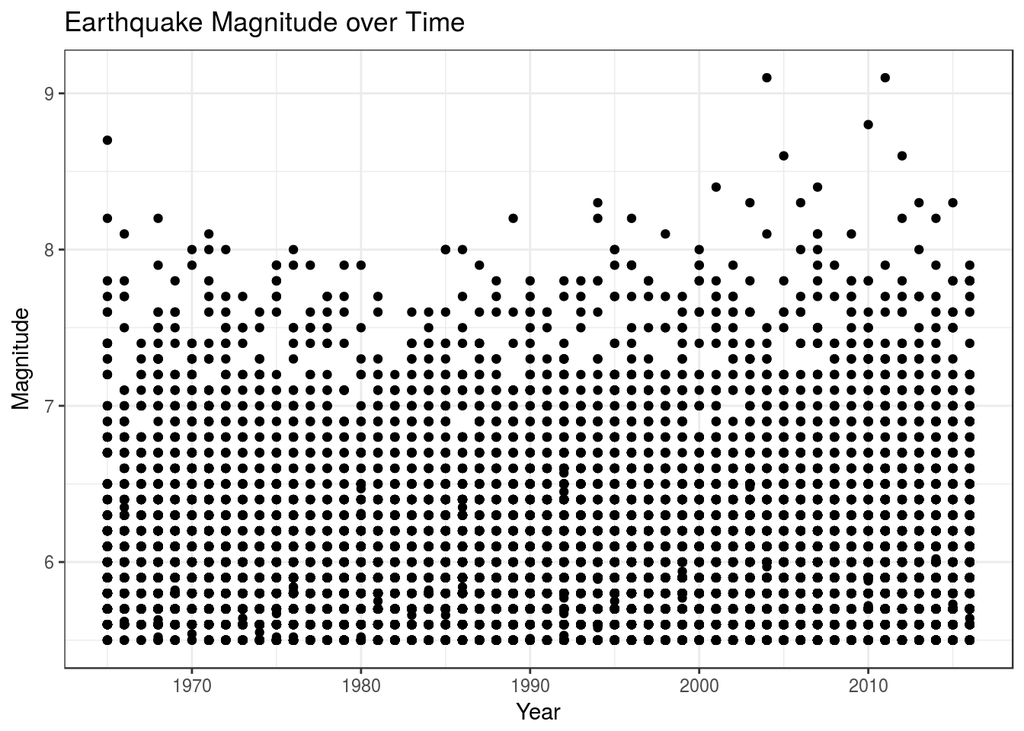

```r
# make a scattplot of year. vs. earthquake magnitude
eq_data %>%
  ggplot(aes(x=Year, y=Magnitude)) +
  geom_point() +
  labs(title="Earthquake Magnitude over Time",
  x = "Year",
  y = "Magnitude")
```

Okay, that’s a lot of data. There’s spikes during some years, but it’s difficult to tell what’s happening. Let’s create a violin plot to visualize the data in a more helpful way.

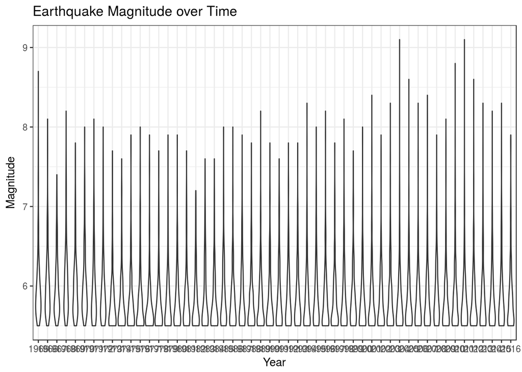

```r
# make a violin plot of year. vs. earthquake magnitude
eq_data %>%
  ggplot(aes(x=factor(Year), y=Magnitude)) +
  geom_violin() +
  labs(title="Earthquake Magnitude over Time",
  x = "Year",
  y = "Magnitude")
```

However, this is still a lot of data. Let’s condense things by plotting Average Earthquake Magnitude and looking at how this changes over time.

```r
# add an average magnitude column to the data
eq_data2 <- eq_data %>%
  group_by(Year) %>%
  mutate(Avg_Magnitude = mean(Magnitude)) %>%
  type_convert(cols(Avg_Magnitude=col_integer()))
```

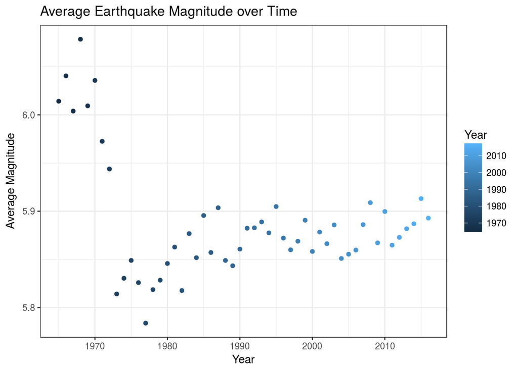

```r
# make a scatter plot of year vs. average earthquake magnitude
eq_data2 %>%
  group_by(Year) %>%
  summarize(Avg_Magnitude = mean(Magnitude)) %>%
  ggplot(aes(x=Year, y=Avg_Magnitude, color=Year)) +
  geom_point() +
    labs(title="Average Earthquake Magnitude over Time",
    x = "Year",
    y = "Average Magnitude")
```

Ahh! This sheds some light on things. The Average Magnitude of earthquakes from 1965-1975 was pretty high, and then dropped back down to 5.8, before fluctuating and increasing over time. Thus, Average Earthquake Magnitude looks like it has a positive correlation with Time after 1975.

### 3. Narrowing Down the Data

Now, can we narrow down our data at all? Since there was an earthquake spike in the early 1970’s, we can plot our data for years after 1972 to remove this predictor. Let’s also take our variables: Average Earthquake Magnitude and Time, and plot these by disaster type and location.

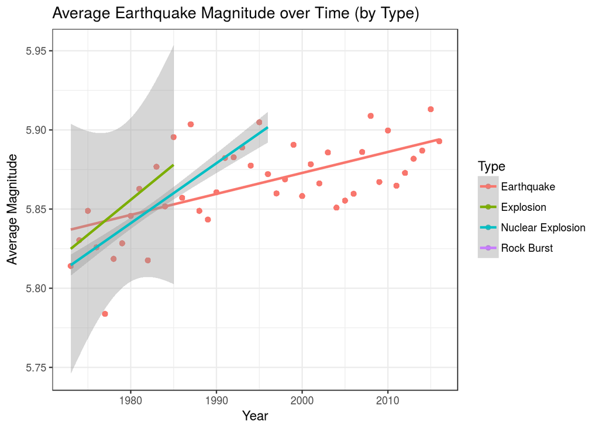

```r
# only work with data > 1972
eq_data3 <- eq_data2 %>%
  filter(Year > 1972)

# plot the linear model for all earthquake types
eq_data3 %>%
  ggplot(aes(x=Year, y=Avg_Magnitude, color=Type)) +
  geom_point() +
  geom_smooth(method=lm) +
    labs(title="Average Earthquake Magnitude over Time (by Type)",
    x = "Year",
    y = "Average Magnitude")
```

By plotting this, we discover that our dataset actually has more types of disasters than earthquakes. However, earthquakes are by far the most common and has the best and broadest distribution for creating a linear model for the data. We will just use earthquakes!

```r
# filter the data by earthquakes only
eq_data4 <- eq_data3 %>%
  filter(Type == "Earthquake")

eq_data4 %>% head()
```

| Year | Time | Latitude | Longitude | Type | Depth | Magnitude | Magnitude.Type | Source | Avg_Magnitude |
| --- | --- | --- | --- | --- | --- | --- | --- | --- | --- |
| 1973 | 11:42:37 | -35.513 | -16.211 | Earthquake | 33 | 6.0 | MS | US | 5.814065 |
| 1973 | 00:53:20 | -9.854 | 117.427 | Earthquake | 66 | 5.5 | MB | US | 5.814065 |
| 1973 | 02:58:17 | -27.716 | -63.261 | Earthquake | 563 | 5.6 | MB | US | 5.814065 |
| 1973 | 14:31:05 | 39.114 | 71.889 | Earthquake | 33 | 5.5 | MB | US | 5.814065 |
| 1973 | 13:54:29 | -38.997 | 175.232 | Earthquake | 150 | 6.2 | MB | US | 5.814065 |
| 1973 | 15:52:42 | -14.665 | 166.384 | Earthquake | 36 | 6.1 | MB | US | 5.814065 |

What about categorizing the data by location?

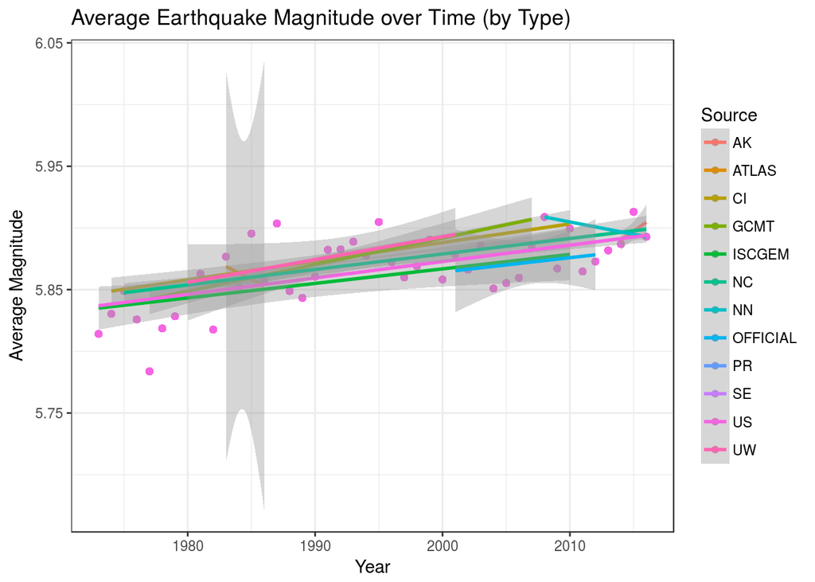

```r
# plot the linear model for all earthquake types
eq_data4 %>%
  ggplot(aes(x=Year, y=Avg_Magnitude, color=Source)) +
  geom_point() +
  geom_smooth(method=lm) +
    labs(title="Average Earthquake Magnitude over Time (by Type)",
    x = "Year",
    y = "Average Magnitude")
```

```r
# filter the data by earthquakes in the US only
eq_data5 <- eq_data4 %>%
  filter(Source == "US")

eq_data5 %>% head()
```

| Year | Time | Latitude | Longitude | Type | Depth | Magnitude | Magnitude.Type | Source | Avg_Magnitude |
| --- | --- | --- | --- | --- | --- | --- | --- | --- | --- |
| 1973 | 11:42:37 | -35.513 | -16.211 | Earthquake | 33 | 6.0 | MS | US | 5.814065 |
| 1973 | 00:53:20 | -9.854 | 117.427 | Earthquake | 66 | 5.5 | MB | US | 5.814065 |
| 1973 | 02:58:17 | -27.716 | -63.261 | Earthquake | 563 | 5.6 | MB | US | 5.814065 |
| 1973 | 14:31:05 | 39.114 | 71.889 | Earthquake | 33 | 5.5 | MB | US | 5.814065 |
| 1973 | 13:54:29 | -38.997 | 175.232 | Earthquake | 150 | 6.2 | MB | US | 5.814065 |
| 1973 | 15:52:42 | -14.665 | 166.384 | Earthquake | 36 | 6.1 | MB | US | 5.814065 |

### 4. Correlate Using a Linear Model

How well does Average Earthquake Magnitude correlate with Time? To answer this question, we need to fit a regression line to the data and display the data. Remember, we’re only plotting earthquake data from after 1972.

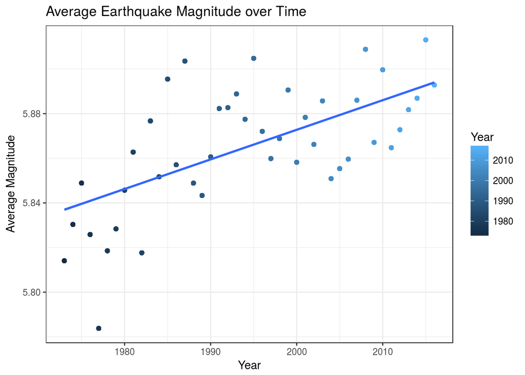

```r
# plot a regression line on the data
eq_data5 %>%
  ggplot(aes(x=Year, y=Avg_Magnitude, color=Year)) +
  geom_point() +
  geom_smooth(method=lm) +
    labs(title="Average Earthquake Magnitude over Time",
    x = "Year",
    y = "Average Magnitude")
```

Fantastic! Now, to find out how well Average Earthquake Magnitude and Time correlate, we can plot a measurement of best fit for the regression line: Residuals. The Residuals tell us how close or far away our data points are from the line by calculating average squared distances.

How do we get the Residuals? We create a linear model. When we create the linear model, a attribute .resid gets created that we can use to plot the Residuals.

```r
# create a linear model
lm_data <- lm(formula=Avg_Magnitude~Year, data = eq_data5)

lm_data %>%
  broom::tidy()
```

| term | estimate | std.error | statistic | p.value |
| --- | --- | --- | --- | --- |
| (Intercept) | 3.219226049 | 2.393334e-02 | 134.5080 | 0 |
| Year | 0.001326772 | 1.199208e-05 | 110.6374 | 0 |

Now, let’s use this linear model to plot the spread of residuals.

[figure not shown]

```r
# plot the residuals of year vs. average earthquake magnitude
lm_data %>%
    ggplot(aes(x=.resid, y=.fitted)) +
    geom_point() +
    geom_smooth(method=lm) +
    labs(title="Residuals of Average Earthquake Magnitude over Time",
         x = "Year",
         y = "Residual")
```